# IODS course project

Karin Helander

# About the project

*It’s all about learning open data, open science and data science with R tools. Testing and analysing!*

My Github repository is: https://github.com/karinhel/IODS-project (:

# Chapter 2 - Linear regression analysis

Let’s begin our analysis by opening the dataset that has been created previously. With the str()-prosedure we see that there are 7 variables of 166 observations. The data describes learning; deep is short for deep learning, stra for strategic learning and surf for surface learning.

```r
students2014 <- read.table(file= "http://s3.amazonaws.com/assets.datacamp.com/production/course_2218/datasets/learning2014.txt", header=T, sep=",")

str(students2014)
```

```
## 'data.frame':    166 obs. of  7 variables:
##  $ gender  : Factor w/ 2 levels "F","M": 1 2 1 2 2 1 2 1 2 1 ...
##  $ age     : int  53 55 49 53 49 38 50 37 37 42 ...
##  $ attitude: num  3.7 3.1 2.5 3.5 3.7 3.8 3.5 2.9 3.8 2.1 ...
##  $ deep    : num  3.58 2.92 3.5 3.5 3.67 ...
##  $ stra    : num  3.38 2.75 3.62 3.12 3.62 ...
##  $ surf    : num  2.58 3.17 2.25 2.25 2.83 ...
##  $ points  : int  25 12 24 10 22 21 21 31 24 26 ...
```

Now that we have the dataset ready, we can start analysing by making some graphs and summaries.

```r
library(GGally)
library(ggplot2)

summary(students2014)
```

```
##  gender       age           attitude          deep            stra
##  F:110   Min.   :17.00   Min.   :1.400   Min.   :1.583   Min.   :1.250
##  M: 56   1st Qu.:21.00   1st Qu.:2.600   1st Qu.:3.333   1st Qu.:2.625
##          Median :22.00   Median :3.200   Median :3.667   Median :3.188
##          Mean   :25.51   Mean   :3.143   Mean   :3.680   Mean   :3.121
##          3rd Qu.:27.00   3rd Qu.:3.700   3rd Qu.:4.083   3rd Qu.:3.625
##          Max.   :55.00   Max.   :5.000   Max.   :4.917   Max.   :5.000
##       surf           points
##  Min.   :1.583   Min.   : 7.00
##  1st Qu.:2.417   1st Qu.:19.00
##  Median :2.833   Median :23.00
##  Mean   :2.787   Mean   :22.72
##  3rd Qu.:3.167   3rd Qu.:27.75
##  Max.   :4.333   Max.   :33.00
```

By using the function summary() we see important statistics of the variables in the data. Only “gender” is a dichotomous variable at the dataset, and all the other variables are continous. However, there are clear minimum and maximum points for each of the 7 variables. The relation between variables can easily be seen in the graph box of all the variables in the model.

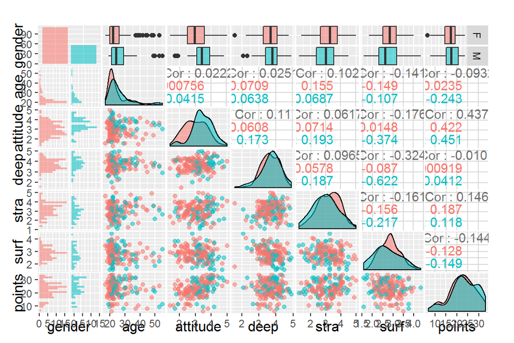

```r
p <- ggpairs(students2014, mapping = aes(col=gender, alpha=0.3), lower = list(combo = wrap("facethist", bins = 20)))

p
```

We see that variables “attitude” and “points” have the biggest correlation in an absolute sense. It seems that there is not any great division for male and female observations of any variable. However, in general the distributions of variables for male observations are “lower” than distributions for female observations, but this can be due to the fact that there are also less male than female answers in the data.

Let’s fit a regression model with variables “attitude” “stra” and “surf” as explanatory variables for target variable exam points, “points”. These explanatory variables have the greatest correlation with “points” and that is why they might form a valid regression model.

```r
the_model <- lm(points ~ attitude + stra + surf, data=students2014 )

summary(the_model)
```

```
##
## Call:
## lm(formula = points ~ attitude + stra + surf, data = students2014)
##
## Residuals:
##      Min       1Q   Median       3Q      Max
## -17.1550  -3.4346   0.5156   3.6401  10.8952
##
## Coefficients:
##             Estimate Std. Error t value Pr(>|t|)
## (Intercept)  11.0171     3.6837   2.991  0.00322 **
## attitude      3.3952     0.5741   5.913 1.93e-08 ***
## stra          0.8531     0.5416   1.575  0.11716
## surf         -0.5861     0.8014  -0.731  0.46563
## ---
## Signif. codes:  0 '***' 0.001 '**' 0.01 '*' 0.05 '.' 0.1 ' ' 1
##
## Residual standard error: 5.296 on 162 degrees of freedom
## Multiple R-squared:  0.2074, Adjusted R-squared:  0.1927
## F-statistic: 14.13 on 3 and 162 DF,  p-value: 3.156e-08
```

At the test statistic’s coefficients part we see that only “attitude” has a significant-enough p-value (the last column). In general, we now have a regression model Y= 11.01 + 3.40 x attitude + 0.85 x stra - 0.59 x surf.

So let’s fit the model again with only the significant variable in p-value sense.

```r
the_model <- lm(points ~ attitude, data=students2014 )

coef(the_model)
```

```
## (Intercept)    attitude
##    11.63715     3.52546
```

When counting coefficents of the new model, we get that the slope b_1=3.52546. It means that when there is a one-unit change in the explanatory variable X, that is “attitude”, points increase by about 3.5 units.

The multiple R-squared tells us the R^2 value =0.21. This is rather small, because it tells, that the explanatory variables only explain about 21% of the variance of the result variable, which is exam points. Adjusted R-squared value tells also about the poor explanation volume; when the number of explanatory variables is included at the review, only around 19% of Y’s variance is explained.

Finally we can interpret the model results with some regression diagnostics plots.

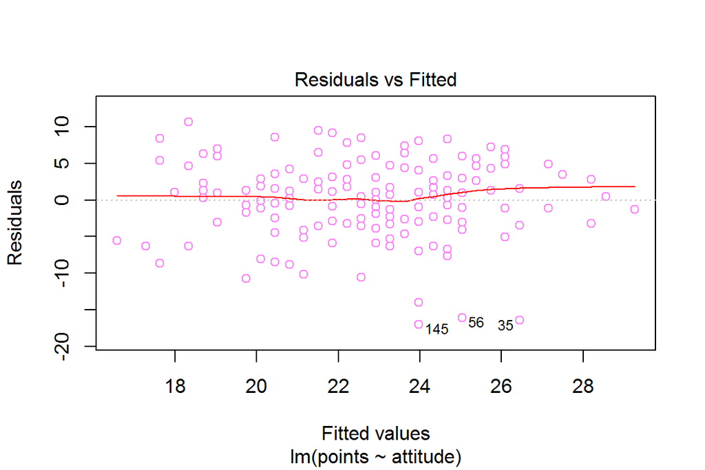

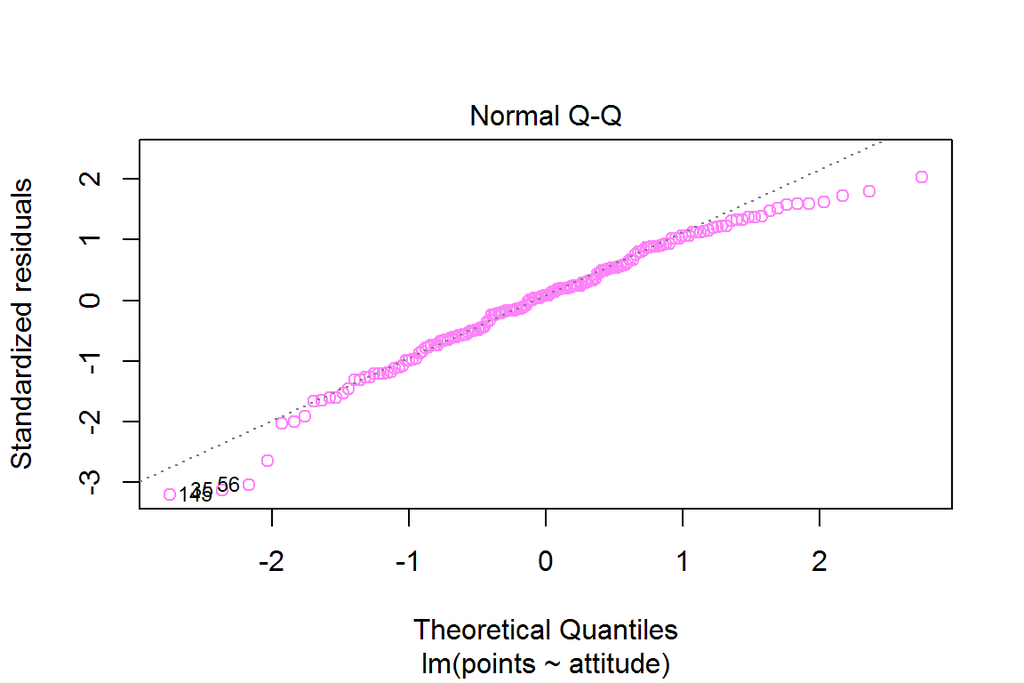

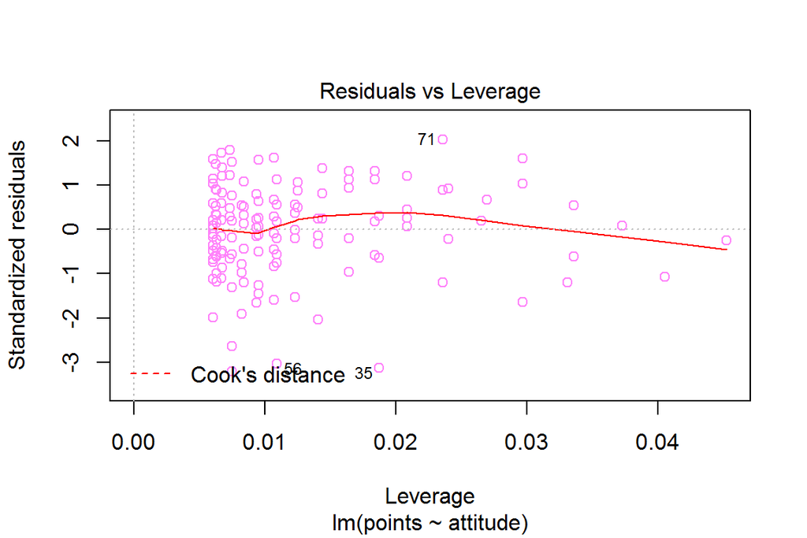

```r
plot(the_model, which=c(1, 2, 5), col="orchid1")
```

“Residuals vs fitted values”-plot shows if the residuals in the model have any non-linear patterns. Luckily there are only a few outliers, observations 145, 56, and 35, that could be removed. We can say that our linear model is a good option for these variables.

With the “Normal Q-Q plot” we can interpret the normality of the residuals, that is the error term. With this model the observations follow quite kindly the line that is drawn in the graph. We can say that normality is approximately true.

“Residuals vs leverage”-plot tells us about “influential cases”, which means it tells whether there are some observations that influence estimates too much and thus will have an effect on the regression line.

# Chapter 3 - Logistic Regression

Let’s start working by opening the dataset with read.table -command and taking a look at the structure of it. The data has been previously merged from two different files.

```r
alc <- read.table(file= "http://s3.amazonaws.com/assets.datacamp.com/production/course_2218/datasets/alc.txt ", header=T, sep=",")

colnames(alc)
```

```
##  [1] "school"     "sex"        "age"        "address"    "famsize"
##  [6] "Pstatus"    "Medu"       "Fedu"       "Mjob"       "Fjob"
## [11] "reason"     "nursery"    "internet"   "guardian"   "traveltime"
## [16] "studytime"  "failures"   "schoolsup"  "famsup"     "paid"
## [21] "activities" "higher"     "romantic"   "famrel"     "freetime"
## [26] "goout"      "Dalc"       "Walc"       "health"     "absences"
## [31] "G1"         "G2"         "G3"         "alc_use"    "high_use"
```

The data addresses alcohol consumptions among 15 to 22 aged students in math and portuguese language courses. The 33 variables that can be seen upon include questions about studying times, grades, other topics related to school, backround information about the person, his/her family and social status and finally alcohol spending on week days and weekends. There are two additional variables; “alc_use” and “high_use”. Alc_use tells the average of week day and weekend alcohol consumption and high_use is a logical vector, which is true if alc_use is higher than two.

At this chapter, the purpose is to study the relationship between four picked variables and the variable “hig_use”. We now choose next four variables;

- “goout” Going out with friends (scale numeric: 1 - very low ; 5 - very high)
- “famrel” Quality of family relationships (numeric: 1 - very bad ; 5 - excellent)
- “studytime” Weekly studytime in hours (numeric: 1 - <2 hours; 2 - 2 to 5 hours; 3 - 5 to 10 hours; 4 - >10 hours)
- “sex” binary: ‘F’ - female or ‘M’ - male

to explain higher use of alcohol in the study group. One could predict that going out with friends will be the best to explain alcohol consumption. Family relationships could have a small effect as well as the studytime. Maybe, if it wasn’t for high_use that we are trying to explain here, it probably would have been better trying to explain high_use’s effect on the weekly studying time than other way around. However, sex could have a greater explanation power on high_use (than “famrel” or “studytime”), but not as great as the first variable “goout”.

First we study the relationships between single variables by crosstabulation and grahps. It seems that among those with high value on “goout” is also more true-values of high_use, which is not suprising. All in all the graphics do not show that mindblowing results and maybe one finds the crosstabulation being more appealing for interpretation.

```r
alc %>% group_by(high_use, sex) %>% summarise(count = n(), mean_goout=mean(goout), mean_famrel=mean(famrel), mean_studytime=mean(studytime))
```

```
## Source: local data frame [4 x 6]
## Groups: high_use [?]
##
##   high_use    sex count mean_goout mean_famrel mean_studytime
##      (lgl) (fctr) (int)      (dbl)       (dbl)          (dbl)
## 1    FALSE      F   157   2.955414    3.917197       2.343949
## 2    FALSE      M   113   2.716814    4.150442       1.876106
## 3     TRUE      F    41   3.390244    3.731707       2.000000
## 4     TRUE      M    71   3.929577    3.774648       1.619718
```

We see that when high_use is true, the mean of going out with friends is greater for both sex. For other two variables we have rather sex divided differencies than a division for false and true high_use values. Here are also bar plots about relationships between the result and explanatory variables, that are merged into one picture with help of this page.

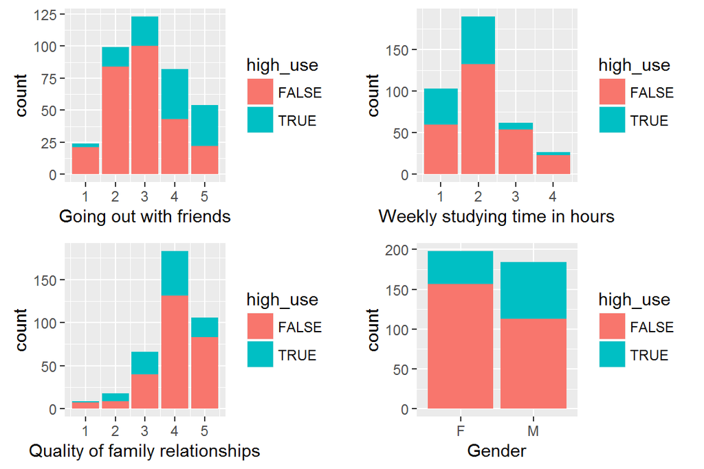

```r
g1 <- ggplot(alc, aes(x = goout, fill=high_use)) + geom_bar() + xlab("Going out with friends")

g2 <- ggplot(alc, aes(x = famrel, fill=high_use)) + geom_bar() + xlab("Quality of family relationships")

g3 <- ggplot(alc, aes(x = studytime, fill=high_use)) + geom_bar() + xlab("Weekly studying time in hours")

g4 <- ggplot(alc, aes(x = sex, fill=high_use)) + geom_bar() + xlab("Gender")

multiplot(g1, g2, g3, g4, cols=2)
```

Next we will fit a model with these four variables as explanatory and high_use as the result variable.

```r
Log <- glm(high_use ~ goout + famrel + studytime + sex, data = alc, family = "binomial")

summary(Log)
```

```
##
## Call:
## glm(formula = high_use ~ goout + famrel + studytime + sex, family = "binomial",
##     data = alc)
##
## Deviance Residuals:
##     Min       1Q   Median       3Q      Max
## -1.5928  -0.7494  -0.4919   0.8250   2.7080
##
## Coefficients:
##             Estimate Std. Error z value Pr(>|z|)
## (Intercept)  -1.2112     0.7142  -1.696  0.08991 .
## goout         0.7947     0.1218   6.523 6.89e-11 ***
## famrel       -0.4496     0.1379  -3.260  0.00111 **
## studytime    -0.4752     0.1703  -2.790  0.00527 **
## sexM          0.7593     0.2655   2.860  0.00424 **
## ---
## Signif. codes:  0 '***' 0.001 '**' 0.01 '*' 0.05 '.' 0.1 ' ' 1
##
## (Dispersion parameter for binomial family taken to be 1)
##
##     Null deviance: 462.21  on 381  degrees of freedom
## Residual deviance: 379.27  on 377  degrees of freedom
## AIC: 389.27
##
## Number of Fisher Scoring iterations: 4
```

In the results we see that the explanatory variables aren’t that bad in p-value sense, at least. “goout” has at least a very significant p-value; it is basically zero. Also the other three variables have significant enough p-values; 0.001, 0.005 and 0.004.

Interpreting the estimated coefficients is a bit more complex than in linear regression, because now we have a binary outcome variable. The backroud for this is that, to make our model linear, we need to fix it with some calculation. The logistic regression model is based on a logistic function and thus the result variable values are actually values of the link function. That is basically the log of odds. This results in the fact that coefficient values can be interpret as odds ratios when we take the exponential of a single coefficient.

In general R is now showing us the value of coeff. when we compare it to a controll group that R has selected automaticly and the real value of this coeff. is calculated: intercept - the value.

After the model has been fit we can calculate OR-values and confidence intervals for the parameters.

```r
OR <- coef(Log) %>% exp

CI <- confint(Log) %>% exp

cbind(OR, CI)
```

```
##                    OR      2.5 %    97.5 %
## (Intercept) 0.2978484 0.07158146 1.1881189
## goout       2.2138196 1.75581193 2.8339395
## famrel      0.6378742 0.48488876 0.8343189
## studytime   0.6217330 0.44091699 0.8617913
## sexM        2.1368457 1.27450527 3.6171734
```

As said earlier, the odds ratios are exponentials of the coefficient values. For example the “goout” variable has an OR value of 2.214. For a one-unit change in “goout” it 2.214 more likely to have a “true” value of high_use than for the non-changed “goout” value. This means that when going out with friends -ratio increases, the alcohol consumption of the observed is over to times more likely to be higher. The odds ratio for “sexM” is also over two. For other two variables in the model the OR values are not that high. It seems that the OR-values and the fitted model correspond to the hypothesis that was made in the beginning.

```r
# predict() the probability of high_use
probabilities <- predict(Log, type = "response")

# add the predicted probabilities to 'alc'
alc <- mutate(alc, probability = probabilities)

# use the probabilities to make a prediction of high_use
alc <- mutate(alc, prediction = probabilities > 0.5)


table(high_use = alc$high_use, prediction = alc$prediction) %>% prop.table %>% addmargins
```

```
##         prediction
## high_use      FALSE       TRUE        Sum
##    FALSE 0.63874346 0.06806283 0.70680628
##    TRUE  0.17277487 0.12041885 0.29319372
##    Sum   0.81151832 0.18848168 1.00000000
```

```r
# define a loss function (mean prediction error)
loss_func <- function(class, prob) {
  n_wrong <- abs(class - prob) > 0.5
  mean(n_wrong)
}

# call loss_func to compute the average number of wrong predictions in the (training) data
loss_func(class = alc$high_use, prob = alc$probability)
```

```
## [1] 0.2408377
```

# Chapter 4 - Clustering and classification

In this chapter we are going to explore one of R’s own data “Boston” of the package MASS. The dataset covers many housing-related topics such as crime rate, taxes, race and pupil-teacher ratio. The primary units of the data are the suburbs of Boston.

First, let’s discover the structure of the data.

```r
data("Boston")

dim(Boston)
```

```
## [1] 506  14
```

```r
str(Boston)
```

```
## 'data.frame':    506 obs. of  14 variables:
##  $ crim   : num  0.00632 0.02731 0.02729 0.03237 0.06905 ...
##  $ zn     : num  18 0 0 0 0 0 12.5 12.5 12.5 12.5 ...
##  $ indus  : num  2.31 7.07 7.07 2.18 2.18 2.18 7.87 7.87 7.87 7.87 ...
##  $ chas   : int  0 0 0 0 0 0 0 0 0 0 ...
##  $ nox    : num  0.538 0.469 0.469 0.458 0.458 0.458 0.524 0.524 0.524 0.524 ...
##  $ rm     : num  6.58 6.42 7.18 7 7.15 ...
##  $ age    : num  65.2 78.9 61.1 45.8 54.2 58.7 66.6 96.1 100 85.9 ...
##  $ dis    : num  4.09 4.97 4.97 6.06 6.06 ...
##  $ rad    : int  1 2 2 3 3 3 5 5 5 5 ...
##  $ tax    : num  296 242 242 222 222 222 311 311 311 311 ...
##  $ ptratio: num  15.3 17.8 17.8 18.7 18.7 18.7 15.2 15.2 15.2 15.2 ...
##  $ black  : num  397 397 393 395 397 ...
##  $ lstat  : num  4.98 9.14 4.03 2.94 5.33 ...
##  $ medv   : num  24 21.6 34.7 33.4 36.2 28.7 22.9 27.1 16.5 18.9 ...
```

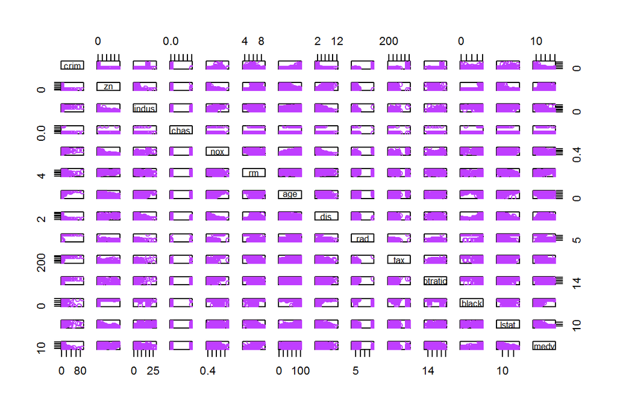

```r
pairs(Boston, col="darkorchid1")
```

We see that there are 506 observations of 14 variables that are mostly numerical. Scatterplots of every variable pair of the data can be seen in the pairs-plot. It is clearly visible that only the variable “chas” is dichotomous with values 0 and 1. The inside pairs correlations or connections differ quite much from each other.

The variable “crim” describes the per capita crime rate by town. Below the summary shows that the crime rate has a large variance. Maybe a better picture of the structure of it we get from the graphical performance. In the scatterplot we have the crime rate on y-axis and it is compared to the median value of owner-occupied homes, variable “medv” in the data. The maximum value of crime rate (88.98) seems to be an outlier better than descriptive data point, because most of the observations are from 0 to about 25. There is some linearity between the home median value and crime rate, but not at the maximum point. It is interesting that when “medv” has it’s max value (50), suddenly crime rate gets also increased values. This would mean that in the towns where median value of owner-occupied homes is $50 000, the per capita crime rate is higher than for lower median values between 30 and >50.

```r
summary(Boston$medv)
```

```
##    Min. 1st Qu.  Median    Mean 3rd Qu.    Max.
##    5.00   17.02   21.20   22.53   25.00   50.00
```

```r
summary(Boston$crim)
```

```
##     Min.  1st Qu.   Median     Mean  3rd Qu.     Max.
##  0.00632  0.08204  0.25650  3.61400  3.67700 88.98000
```

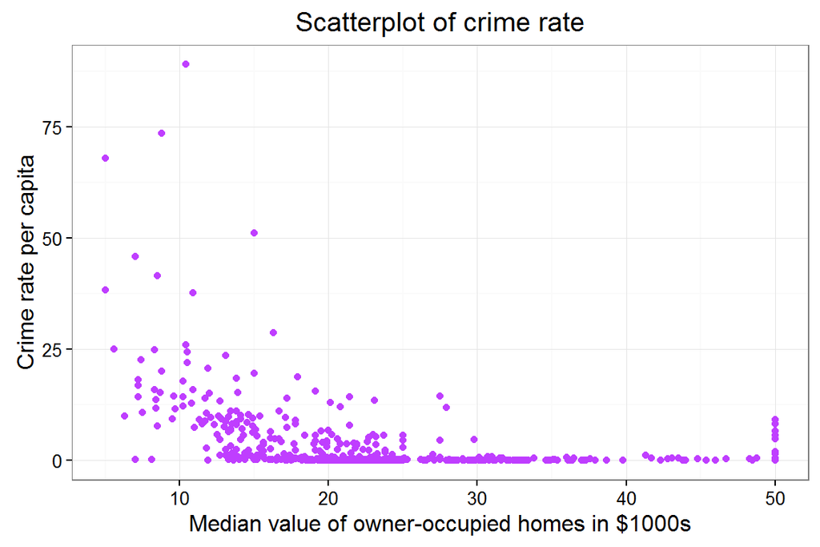

```r
p <- ggplot(Boston, aes(x=medv, y=crim)) + geom_point(col="darkorchid1") + ylab("Crime rate per capita") + xlab("Median value of owner-occupied homes in $1000s") + ggtitle("Scatterplot of crime rate")
p + theme_bw()
```

Before linear discriminant analysis we must scale the data and divide it to two subsets; test set and train set. First the scaling;

```r
boston_scaled <- scale(Boston)
boston_scaled <- as.data.frame(boston_scaled)

summary(boston_scaled)
```

```
##       crim                 zn               indus
##  Min.   :-0.419367   Min.   :-0.48724   Min.   :-1.5563
##  1st Qu.:-0.410563   1st Qu.:-0.48724   1st Qu.:-0.8668
##  Median :-0.390280   Median :-0.48724   Median :-0.2109
##  Mean   : 0.000000   Mean   : 0.00000   Mean   : 0.0000
##  3rd Qu.: 0.007389   3rd Qu.: 0.04872   3rd Qu.: 1.0150
##  Max.   : 9.924110   Max.   : 3.80047   Max.   : 2.4202
##       chas              nox                rm               age
##  Min.   :-0.2723   Min.   :-1.4644   Min.   :-3.8764   Min.   :-2.3331
##  1st Qu.:-0.2723   1st Qu.:-0.9121   1st Qu.:-0.5681   1st Qu.:-0.8366
##  Median :-0.2723   Median :-0.1441   Median :-0.1084   Median : 0.3171
##  Mean   : 0.0000   Mean   : 0.0000   Mean   : 0.0000   Mean   : 0.0000
##  3rd Qu.:-0.2723   3rd Qu.: 0.5981   3rd Qu.: 0.4823   3rd Qu.: 0.9059
##  Max.   : 3.6648   Max.   : 2.7296   Max.   : 3.5515   Max.   : 1.1164
##       dis               rad               tax             ptratio
##  Min.   :-1.2658   Min.   :-0.9819   Min.   :-1.3127   Min.   :-2.7047
##  1st Qu.:-0.8049   1st Qu.:-0.6373   1st Qu.:-0.7668   1st Qu.:-0.4876
##  Median :-0.2790   Median :-0.5225   Median :-0.4642   Median : 0.2746
##  Mean   : 0.0000   Mean   : 0.0000   Mean   : 0.0000   Mean   : 0.0000
##  3rd Qu.: 0.6617   3rd Qu.: 1.6596   3rd Qu.: 1.5294   3rd Qu.: 0.8058
##  Max.   : 3.9566   Max.   : 1.6596   Max.   : 1.7964   Max.   : 1.6372
##      black             lstat              medv
##  Min.   :-3.9033   Min.   :-1.5296   Min.   :-1.9063
##  1st Qu.: 0.2049   1st Qu.:-0.7986   1st Qu.:-0.5989
##  Median : 0.3808   Median :-0.1811   Median :-0.1449
##  Mean   : 0.0000   Mean   : 0.0000   Mean   : 0.0000
##  3rd Qu.: 0.4332   3rd Qu.: 0.6024   3rd Qu.: 0.2683
##  Max.   : 0.4406   Max.   : 3.5453   Max.   : 2.9865
```

Scaling the data affected in the level of the variables; now every variable has the mean of 0. Thus they all vary in both sides of the same mean value.

Next we are going to create a categorical variable of the variable “crim” in our scaled data. This is done by using the quantiles as the break points in the categorical variable.

```r
scaled_crim <- boston_scaled$crim

# a quantile vector of crim
bins <- quantile(scaled_crim)

# creating the categorical variable
crime <- cut(scaled_crim, breaks = bins, include.lowest = TRUE, labels = c("low", "med_low", "med_high", "high"))

table(crime)
```

```
## crime
##      low  med_low med_high     high
##      127      126      126      127
```

```r
# removing original crim from the dataset
boston_scaled <- dplyr::select(boston_scaled, -crim)

# adding the new categorical value to scaled data
boston_scaled <- data.frame(boston_scaled, crime)
```

Now let’s divide the data to train and test sets.

```r
# number of rows
n <- nrow(boston_scaled)

# choosing 80% of the rows
ind <- sample(n,  size = n * 0.8)

# train set
train <- boston_scaled[ind,]

# test set
test <- boston_scaled[-ind,]
```

Now, we will run the linear discriminant analysis using the categorical crime rate as the target variable and all the other variables as predictors.

```r
# linear discriminant analysis
lda.fit <- lda(crime ~ ., data = train)

# print the lda.fit object
lda.fit
```

```
## Call:
## lda(crime ~ ., data = train)
##
## Prior probabilities of groups:
##       low   med_low  med_high      high
## 0.2326733 0.2475248 0.2524752 0.2673267
##
## Group means:
##                   zn      indus         chas        nox           rm
## low       0.93888074 -0.9140513 -0.062908842 -0.8678021  0.485545862
## med_low  -0.07068881 -0.3286097  0.003267949 -0.6038787 -0.122491158
## med_high -0.38551208  0.2037690  0.113661151  0.4376745 -0.002368002
## high     -0.48724019  1.0169921 -0.090055909  1.0795974 -0.422751620
##                 age        dis        rad        tax    ptratio
## low      -0.8952937  0.8622021 -0.6886456 -0.7202336 -0.5022983
## med_low  -0.4409379  0.4478234 -0.5466022 -0.5469250 -0.1074085
## med_high  0.4300178 -0.3821395 -0.4042598 -0.2986012 -0.2842277
## high      0.8195551 -0.8433752  1.6393984  1.5149640  0.7822555
##                black       lstat         medv
## low       0.37883222 -0.80399267  0.548294935
## med_low   0.35588167 -0.16690281  0.002086926
## med_high  0.06683244  0.06912186  0.078513370
## high     -0.82216253  0.88194841 -0.700042298
##
## Coefficients of linear discriminants:
##                 LD1         LD2         LD3
## zn       0.07044270  0.71990360 -1.02618378
## indus   -0.05124270 -0.23921321  0.46780311
## chas    -0.09186055  0.01362845  0.12391823
## nox      0.36642901 -0.61629751 -1.21594826
## rm      -0.09219257 -0.01834707 -0.09887774
## age      0.25234850 -0.35006671 -0.21971113
## dis     -0.17369923 -0.15126051  0.32604457
## rad      2.86937568  0.95129978  0.36611347
## tax      0.10513100 -0.02507845  0.04833756
## ptratio  0.12953565  0.05581081 -0.33510899
## black   -0.12060223 -0.01583789  0.15110895
## lstat    0.22283093 -0.20634794  0.37532040
## medv     0.17271013 -0.34044824 -0.23419619
##
## Proportion of trace:
##    LD1    LD2    LD3
## 0.9457 0.0401 0.0141
```

From the results we see for example the propabilities for every group of the variable “crime”, then group means and propabilities for every ld model. We see that R has constructed three ld groups, which is one less than the groups of “crime”.

Let’s then draw the LDA biplot with informative arrows. We use colour groups that are our ld model classes.

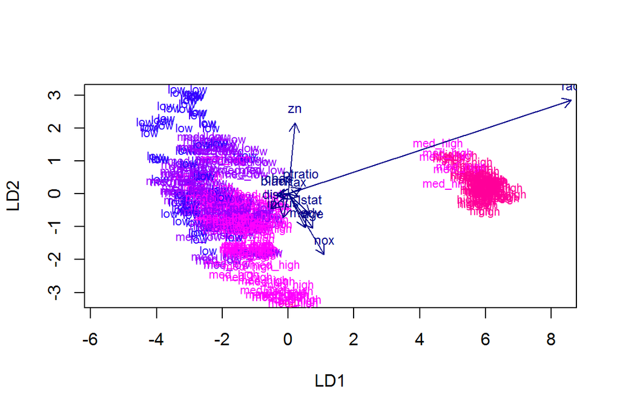

```r
# lda biplot arrows
lda.arrows <- function(x, myscale = 1, arrow_heads = 0.1, color = "red", tex = 0.75, choices = c(1,2)){
  heads <- coef(x)
  arrows(x0 = 0, y0 = 0,
         x1 = myscale * heads[,choices[1]],
         y1 = myscale * heads[,choices[2]], col=color, length = arrow_heads)
  text(myscale * heads[,choices], labels = row.names(heads),
       cex = tex, col=color, pos=3)
}

# target classes as numeric
classes <- as.numeric(train$crime)

plot(lda.fit, dimen = 2, col=rainbow(4, start = 0.7, end = 0.9)[classes], pch=classes)
lda.arrows(lda.fit, myscale = 3, col="darkblue")
```

Before we can use the test data for some further predictions, we should save the crime categories from the test data and then remove the categorical crime variable.

```r
# saving the correct classes from test set
correct_classes <- test$crime

# removing the crime variable from test data
test <- dplyr::select(test, -crime)
```

Now we will predict the classes with the LDA model and cross tabulate the results with the crime categories from the test set.

```r
lda.pred <- predict(lda.fit, newdata = test)

table(correct = correct_classes, predicted = lda.pred$class)
```

```
##           predicted
## correct    low med_low med_high high
##   low       16      14        3    0
##   med_low    3      11       12    0
##   med_high   0       6       18    0
##   high       0       0        0   19
```

We can now move on to the most interesting part of the chapter, K-means clustering. For this we reload the Boston dataset and standardize it. After that we can calculate distance measures using the euklidean and manhattan distance.

```r
data("Boston")

boston_stand <- scale(Boston)
boston_stand <- as.data.frame(boston_stand)

# Euklidean distance
dist_eu <- dist(boston_stand)
summary(dist_eu)
```

```
##    Min. 1st Qu.  Median    Mean 3rd Qu.    Max.
##  0.1343  3.4620  4.8240  4.9110  6.1860 14.4000
```

```r
# Manhattan distance
dist_man <- dist(boston_stand, method="manhattan")
summary(dist_man)
```

```
##    Min. 1st Qu.  Median    Mean 3rd Qu.    Max.
##  0.2662  8.4830 12.6100 13.5500 17.7600 48.8600
```

Using the euklidean distance measure we run the k-means clustering algorithm on the data. To find the optimal number of clusters we can investigate the within cluster sum of squares (WCSS) measure by drawing a plot of the total WCSS values for each number of clusters.

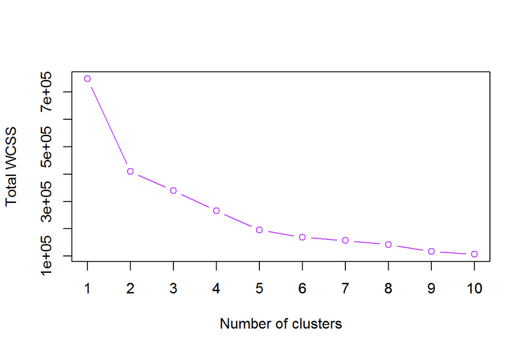

```r
set.seed(123)

# The total within sum of squares
k_max <- 10
twcss <- sapply(1:k_max, function(k){kmeans(dist_eu, k)$tot.withinss})

# visualize the results
plot(1:k_max, twcss, type='b', col="darkorchid1", xlab="Number of clusters", ylab="Total WCSS")
axis(1, at=1:10)
```

```r
km <-kmeans(dist_eu, centers = 4)
```

We find that the most radical change in WCSS is when there are 2 clusters. So we will try K-means with 2 centers.

```r
km1 <-kmeans(dist_eu, centers = 2)
```

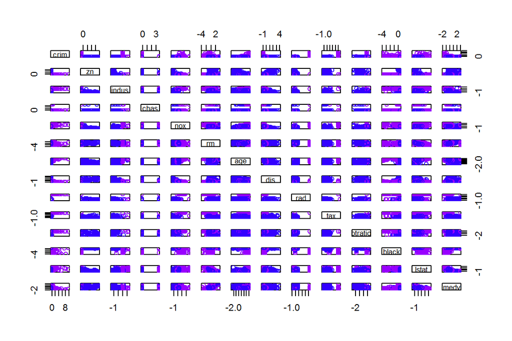

```r
pairs(boston_stand, col=rainbow(4, start = 0.7, end = 0.9)[km1$cluster])
```

# Chapter 5 - Dimensionality reduction techniques

- Part 1 - the “Human” data

We will start working by opening the data that has been wrangled before for analysis purposes. The dataset has 155 observations of 8 variables. It considers education, life expectation, labour force participation and parliamentary representation in different countries in the world.

```
## [1] 155   8
```

```
## 'data.frame':    155 obs. of  8 variables:
##  $ Edu2.FM  : num  1.007 0.997 0.983 0.989 0.969 ...
##  $ Labo.FM  : num  0.891 0.819 0.825 0.884 0.829 ...
##  $ Edu.Exp  : num  17.5 20.2 15.8 18.7 17.9 16.5 18.6 16.5 15.9 19.2 ...
##  $ Life.Exp : num  81.6 82.4 83 80.2 81.6 80.9 80.9 79.1 82 81.8 ...
##  $ GNI      : int  64992 42261 56431 44025 45435 43919 39568 52947 42155 32689 ...
##  $ Mat.Mor  : int  4 6 6 5 6 7 9 28 11 8 ...
##  $ Ado.Birth: num  7.8 12.1 1.9 5.1 6.2 3.8 8.2 31 14.5 25.3 ...
##  $ Parli.F  : num  39.6 30.5 28.5 38 36.9 36.9 19.9 19.4 28.2 31.4 ...
```

```r
library(ggplot2)
library(GGally)

summary(human)
```

```
##     Edu2.FM          Labo.FM          Edu.Exp         Life.Exp
##  Min.   :0.1717   Min.   :0.1857   Min.   : 5.40   Min.   :49.00
##  1st Qu.:0.7264   1st Qu.:0.5984   1st Qu.:11.25   1st Qu.:66.30
##  Median :0.9375   Median :0.7535   Median :13.50   Median :74.20
##  Mean   :0.8529   Mean   :0.7074   Mean   :13.18   Mean   :71.65
##  3rd Qu.:0.9968   3rd Qu.:0.8535   3rd Qu.:15.20   3rd Qu.:77.25
##  Max.   :1.4967   Max.   :1.0380   Max.   :20.20   Max.   :83.50
##       GNI            Mat.Mor         Ado.Birth         Parli.F
##  Min.   :   581   Min.   :   1.0   Min.   :  0.60   Min.   : 0.00
##  1st Qu.:  4198   1st Qu.:  11.5   1st Qu.: 12.65   1st Qu.:12.40
##  Median : 12040   Median :  49.0   Median : 33.60   Median :19.30
##  Mean   : 17628   Mean   : 149.1   Mean   : 47.16   Mean   :20.91
##  3rd Qu.: 24512   3rd Qu.: 190.0   3rd Qu.: 71.95   3rd Qu.:27.95
##  Max.   :123124   Max.   :1100.0   Max.   :204.80   Max.   :57.50
```

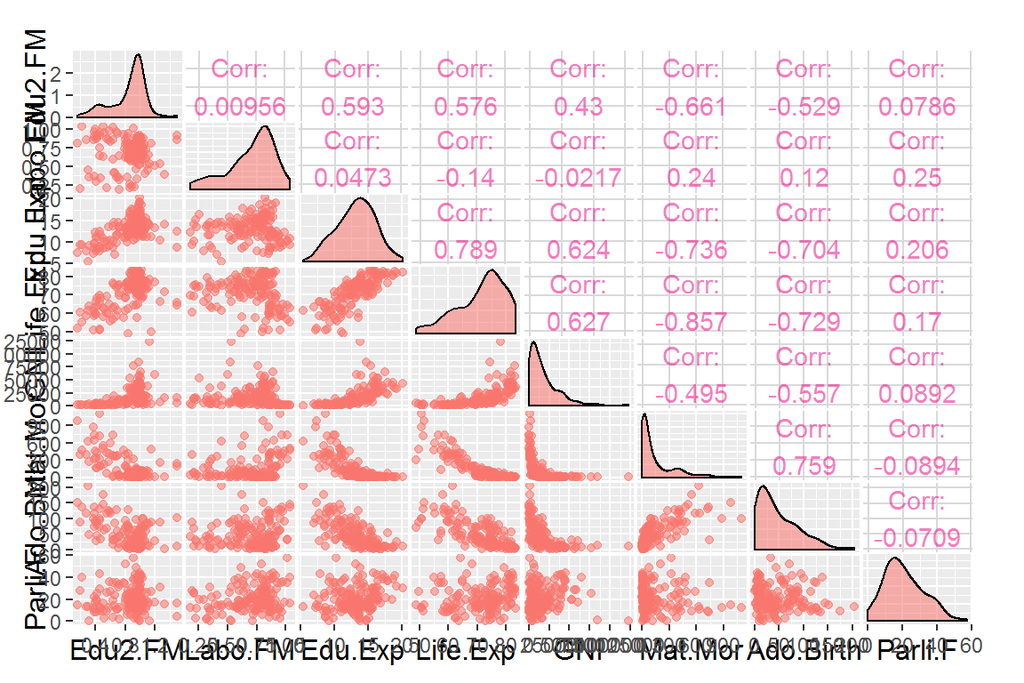

```r
p <- ggpairs(human, mapping = aes(col="deeppink2", alpha=0.3), lower = list(combo = wrap("facethist", bins = 20)))

p
```

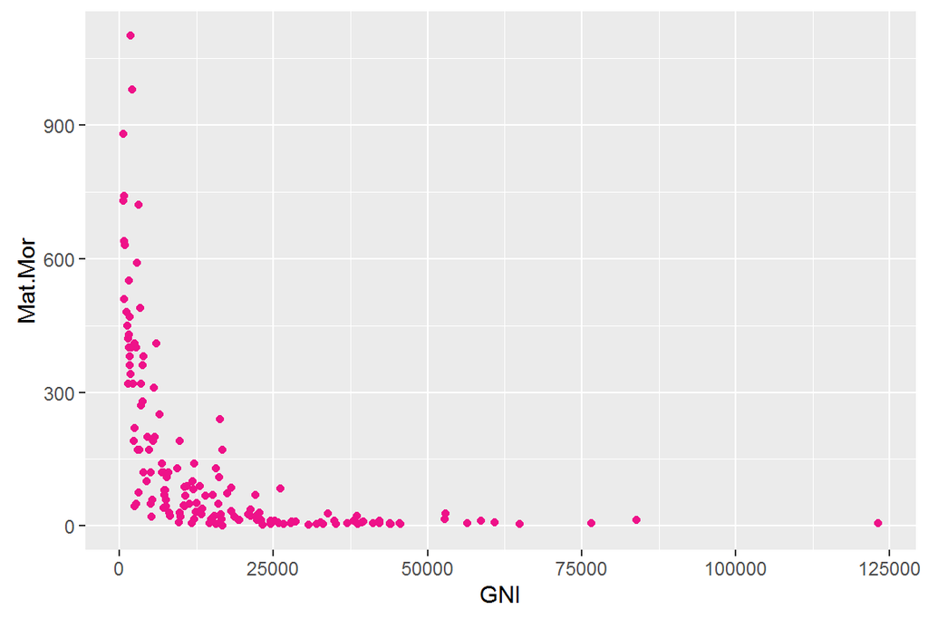

```r
p2 <- ggplot(human, aes(x=GNI, y= Mat.Mor)) + geom_point(col="deeppink2")

p2
```

The scatterplot shows that when GNI is low, the maternal mortality is much higher than with greater values of GNI. This makes sense, because maternal mortality is known to be approximately zero in any welfare state.

Next we will perform a principal component analysis.

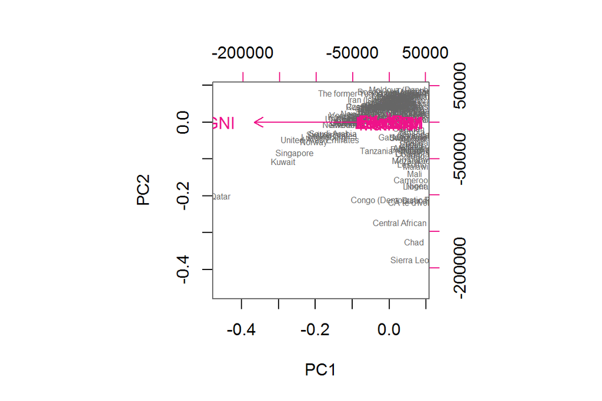

```r
pca_human <- prcomp(human)

biplot(pca_human, choices = 1:2, cex = c(0.5, 1), col = c("grey40", "deeppink2"))
```

In the biplot nearly all of the observations are in the corner on the right. The plot is hard to interpret because the arrows and observations cannot be seen clearly. There is no visible correlation between the features and principal components. Better results will probably occur after standardising the data, so let’s do the standardization next.

```r
human_std <- scale(human)
```

Now we can perform the principal component analysis with the standardized ‘human’ data.

```r
# perform principal component analysis (with the SVD method)
pca_human2 <- prcomp(human_std)

summary(pca_human2)
```

```
## Importance of components:
##                           PC1    PC2     PC3     PC4     PC5     PC6
## Standard deviation     2.0708 1.1397 0.87505 0.77886 0.66196 0.53631
## Proportion of Variance 0.5361 0.1624 0.09571 0.07583 0.05477 0.03595
## Cumulative Proportion  0.5361 0.6984 0.79413 0.86996 0.92473 0.96069
##                            PC7     PC8
## Standard deviation     0.45900 0.32224
## Proportion of Variance 0.02634 0.01298
## Cumulative Proportion  0.98702 1.00000
```

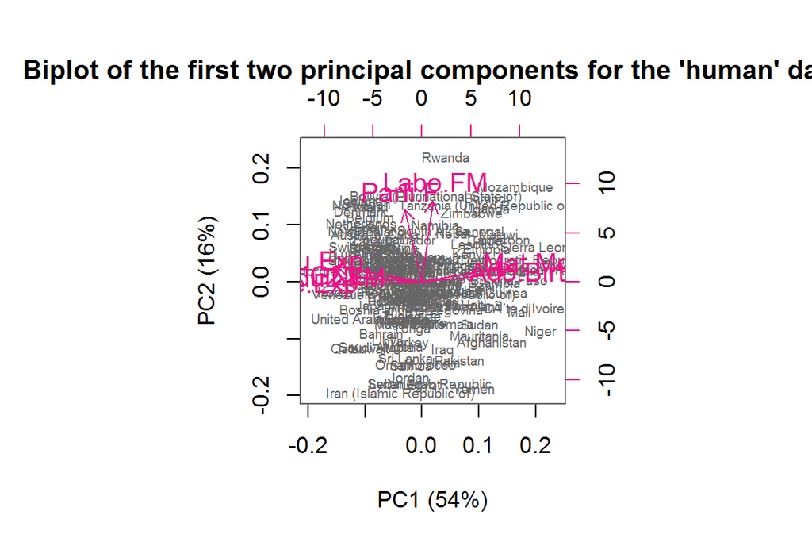

```r
biplot(pca_human2, choices = 1:2, cex = c(0.6, 1.2), col = c("grey40", "deeppink2"), main="Biplot of the first two principal components for the 'human' data", xlab="PC1 (54%)", ylab="PC2 (16%)")
```

This biplot is much more informatic, as the observations are clearer and the arrows now show the relationships between the variables in the dataset. This is due to the standardation which have made the variances of the variables more comparable. The PCA procedure assumes a feature with a large variance to be more important than one with a small variance, regardless of the scaling of features. If the data is not standardized, the comparison will probably become biased due to the non-similar scaling.

The summary of the PCA tells that PC1 has nearly 54% of the variance of the data and the second PC2 has just 16%. Together they have around 70% of the variance of the features, so there is a good reason to use only these first two PC’s in the biplot and analysis.

- Part 2 - the “tea” data from package FactoMineR

Let’s first install the package and data in question.

```r
library(FactoMineR)

data("tea")
```

```r
dim(tea)
```

```
## [1] 300  36
```

```r
str(tea)
```

```
## 'data.frame':    300 obs. of  36 variables:
##  $ breakfast       : Factor w/ 2 levels "breakfast","Not.breakfast": 1 1 2 2 1 2 1 2 1 1 ...
##  $ tea.time        : Factor w/ 2 levels "Not.tea time",..: 1 1 2 1 1 1 2 2 2 1 ...
##  $ evening         : Factor w/ 2 levels "evening","Not.evening": 2 2 1 2 1 2 2 1 2 1 ...
##  $ lunch           : Factor w/ 2 levels "lunch","Not.lunch": 2 2 2 2 2 2 2 2 2 2 ...
##  $ dinner          : Factor w/ 2 levels "dinner","Not.dinner": 2 2 1 1 2 1 2 2 2 2 ...
##  $ always          : Factor w/ 2 levels "always","Not.always": 2 2 2 2 1 2 2 2 2 2 ...
##  $ home            : Factor w/ 2 levels "home","Not.home": 1 1 1 1 1 1 1 1 1 1 ...
##  $ work            : Factor w/ 2 levels "Not.work","work": 1 1 2 1 1 1 1 1 1 1 ...
##  $ tearoom         : Factor w/ 2 levels "Not.tearoom",..: 1 1 1 1 1 1 1 1 1 2 ...
##  $ friends         : Factor w/ 2 levels "friends","Not.friends": 2 2 1 2 2 2 1 2 2 2 ...
##  $ resto           : Factor w/ 2 levels "Not.resto","resto": 1 1 2 1 1 1 1 1 1 1 ...
##  $ pub             : Factor w/ 2 levels "Not.pub","pub": 1 1 1 1 1 1 1 1 1 1 ...
##  $ Tea             : Factor w/ 3 levels "black","Earl Grey",..: 1 1 2 2 2 2 2 1 2 1 ...
##  $ How             : Factor w/ 4 levels "alone","lemon",..: 1 3 1 1 1 1 1 3 3 1 ...
```

[output cut: 22 more lines]

There are 300 observations of 36 variables in the data, which in general describes tea drinking. Since 36 variables is quite much to handly and unnecessarily large number for a multiple correspondence analysis, we will take our own subset of the data. The picked variables can be seen at the stucture of the new dataset ‘teatime’ below.

```r
keep <- c("breakfast", "Tea", "How", "age_Q", "frequency")

teatime <- dplyr::select(tea, one_of(keep))

str(teatime)
```

```
## 'data.frame':    300 obs. of  5 variables:
##  $ breakfast: Factor w/ 2 levels "breakfast","Not.breakfast": 1 1 2 2 1 2 1 2 1 1 ...
##  $ Tea      : Factor w/ 3 levels "black","Earl Grey",..: 1 1 2 2 2 2 2 1 2 1 ...
##  $ How      : Factor w/ 4 levels "alone","lemon",..: 1 3 1 1 1 1 1 3 3 1 ...
##  $ age_Q    : Factor w/ 5 levels "15-24","25-34",..: 3 4 4 1 4 1 3 3 3 3 ...
##  $ frequency: Factor w/ 4 levels "1/day","1 to 2/week",..: 1 1 3 1 3 1 4 2 3 3 ...
```

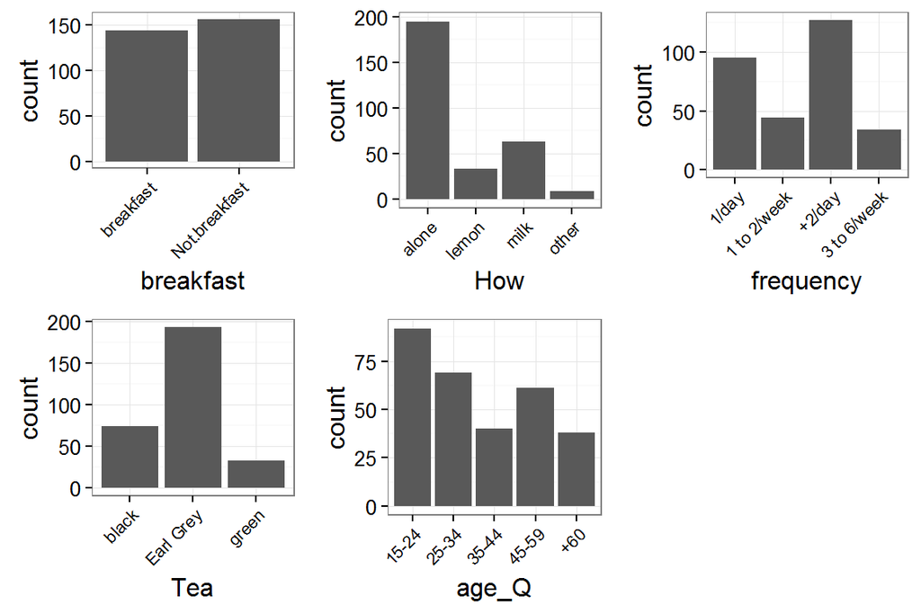

```r
g1 <- ggplot(teatime, aes(breakfast)) + geom_bar() + theme_bw() + theme(axis.text.x = element_text(angle = 45, hjust = 1, size = 8))
g2 <- ggplot(teatime, aes(Tea)) + geom_bar()+ theme_bw() + theme(axis.text.x = element_text(angle = 45, hjust = 1, size = 8))
g3 <- ggplot(teatime, aes(How)) + geom_bar()+ theme_bw() + theme(axis.text.x = element_text(angle = 45, hjust = 1, size = 8))
g4 <- ggplot(teatime, aes(age_Q)) + geom_bar()+ theme_bw() + theme(axis.text.x = element_text(angle = 45, hjust = 1, size = 8))
g5 <- ggplot(teatime, aes(frequency)) + geom_bar()+ theme_bw() + theme(axis.text.x = element_text(angle = 45, hjust = 1, size = 8))

multiplot(g1, g2, g3, g4, g5, cols=3)
```

The most, there are earl grey drinking respondents who drink tea at least twice a day. It seems that about half of the respondents drink tea with breakfast and the other half, on the other hand, does not. If we would take a closer look at the ‘frequency’ variable we should then change the order of the levels because now they do not seem to be logical. However, that is not what we are going to do right now.

Instead, we will now perform a Multiple Correspondence Analysis (MCA) on the new dataset.

```r
mca <- MCA(X = teatime, graph=F)

summary(mca)
```

```
##
## Call:
## MCA(X = teatime, graph = F)
##
##
## Eigenvalues
##                        Dim.1   Dim.2   Dim.3   Dim.4   Dim.5   Dim.6
## Variance               0.317   0.288   0.248   0.231   0.214   0.209
## % of var.             12.205  11.079   9.532   8.870   8.241   8.036
## Cumulative % of var.  12.205  23.285  32.817  41.686  49.927  57.963
##                        Dim.7   Dim.8   Dim.9  Dim.10  Dim.11  Dim.12
## Variance               0.196   0.184   0.177   0.157   0.150   0.125
## % of var.              7.557   7.090   6.801   6.024   5.784   4.811
## Cumulative % of var.  65.520  72.610  79.411  85.435  91.219  96.031
##                       Dim.13
## Variance               0.103
## % of var.              3.969
## Cumulative % of var. 100.000
##
## Individuals (the 10 first)
##                  Dim.1    ctr   cos2    Dim.2    ctr   cos2    Dim.3
## 1             |  0.532  0.297  0.106 |  0.221  0.057  0.018 |  0.025
## 2             |  0.947  0.941  0.321 | -0.164  0.031  0.010 |  0.599
## 3             | -0.066  0.005  0.003 | -0.101  0.012  0.007 | -0.064
## 4             | -0.613  0.394  0.292 | -0.292  0.099  0.066 | -0.154
## 5             |  0.392  0.162  0.103 | -0.492  0.280  0.162 | -0.109
## 6             | -0.613  0.394  0.292 | -0.292  0.099  0.066 | -0.154
## 7             | -0.092  0.009  0.003 |  0.262  0.080  0.021 | -0.455
## 8             |  0.080  0.007  0.002 |  0.876  0.888  0.191 | -0.200
## 9             |  0.721  0.547  0.196 | -0.352  0.143  0.047 | -0.247
## 10            |  0.770  0.623  0.237 |  0.238  0.065  0.023 | -0.454
##                  ctr   cos2
## 1              0.001  0.000 |
## 2              0.483  0.129 |
## 3              0.006  0.003 |
## 4              0.032  0.018 |
## 5              0.016  0.008 |
## 6              0.032  0.018 |
## 7              0.279  0.063 |
## 8              0.054  0.010 |
```

[output cut: 19 more lines]

```
## Earl Grey      -9.415 |  -0.215   2.395   0.083  -4.988 |
## green           2.854 |   1.675  24.904   0.347  10.182 |
## alone          -0.740 |  -0.136   0.969   0.034  -3.202 |
## lemon           1.576 |   0.328   0.956   0.013   1.995 |
## milk           -3.217 |   0.407   2.814   0.044   3.633 |
## other           6.861 |  -1.111   2.990   0.038  -3.379 |
## 15-24          -6.043 |  -0.903  20.174   0.361 -10.383 |
##
## Categorical variables (eta2)
##                 Dim.1 Dim.2 Dim.3
## breakfast     | 0.416 0.275 0.003 |
## Tea           | 0.263 0.307 0.347 |
## How           | 0.303 0.188 0.096 |
## age_Q         | 0.226 0.407 0.485 |
## frequency     | 0.379 0.264 0.309 |
```

The output of MCA gives us Eigenvalues, values for individuals and categories. In the output, at the Categories table there are the v.test values. A v-test value is +/-1.96 if the coordinate in question is significantly different from zero. There are only a few coordinates less than |1.96|, so nearly all of them are significant.

A graphical overview is performed by the MCA factor map below.

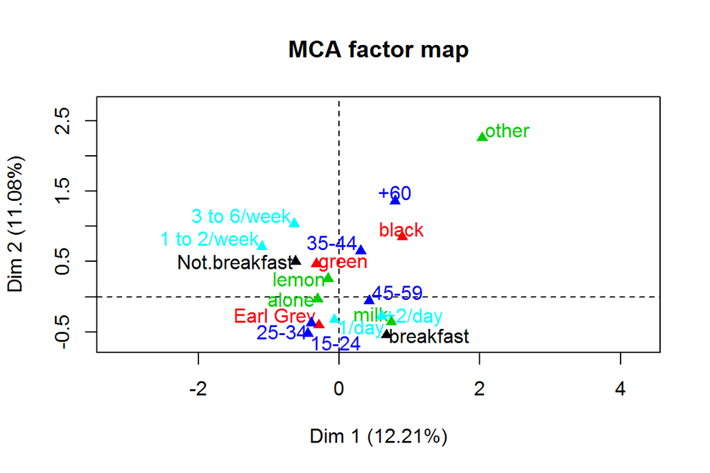

```r
plot(mca, invisible=c("ind"), habillage = "quali")
```

This MCA biplot gives us a good overview of the similarity of the categories on the first two dimensions. The only outstanding category is the ‘other’ value of the variable ‘How’. We find that the categories ‘15-24’ and ‘25-34’ (years) are really close to ‘Earl Grey’ while older age categories are closer to ‘Black’. So maybe the younger respondents prefer earl grey tea to other options. It is also interesting that categories ‘Not.breakfast’ and ‘green’ are close to each other, because this indicates that those not drinking tea for breakfast prefer green tea.